# S&P 500 Machine Learning Project

Chuck Moore

2024-10-15

# S&P 500 Analysis and Findings

## Introduction

The S&P 500 Project was completed in order to discover if specific features such as sector, market cap, number of employees, etc. contribute to a company in the S&P 500 having a revenue growth over ten percent.

Data used in this project comes from https://www.kaggle.com/datasets/andrewmvd/sp-500-stocks/data. The data is up to date to 9/16/2024.

Two machine learning models were used, logistic regression and gradient boosting in an attempt to find out which features if any, contribute to a company exceeding ten percent in revenue growth.

## Data Preparation

```r
library(tidymodels)
library(tidyverse)
library(dplyr)
library(vip)
library(earth)
library(caret)
library(xgboost)

options(scipen = 999)
sp500_data <- read.csv("sp500_companies_ml.csv", sep = ",", header = TRUE, fileEncoding = "UTF-8")

colSums(is.na(sp500_data))
```

```
##            Exchange              Symbol           Shortname            Longname
##                   0                   0                   0                   0
##              Sector            Industry        Currentprice           Marketcap
##                   0                   0                   0                   0
##              Ebitda       Revenuegrowth                City               State
##                  29                   2                   0                   0
##             Country   Fulltimeemployees Longbusinesssummary              Weight
##                   0                   5                   0                   0
```

```r
sp500_change <- sp500_data %>%
  mutate(Exceptional_growth = ifelse(Revenuegrowth > 0.1, 1, 0)) %>%
  select(-Industry, -Currentprice, -Weight, -Revenuegrowth, -State, -Exchange, -Symbol, -Country, -Longbusinesssummary, -Longname, -Shortname, -City) %>%
  na.omit()

sp500_final <- mutate(Sector = factor(Sector), sp500_change, Exceptional_growth = factor(Exceptional_growth))
```

## Logistic Regression Model

```r
set.seed(123)
sp_split <- initial_split(sp500_final, prop = 0.7, strata = "Exceptional_growth")
sp_train <- training(sp_split)
sp_test <- testing(sp_split)

set.seed(123)
kfold <- vfold_cv(sp_train, v = 5)

results <- logistic_reg() %>%
  fit_resamples(Exceptional_growth ~ ., kfold)

final_fit <- logistic_reg() %>%
  fit(Exceptional_growth ~ ., data = sp_train)
tidy(final_fit)
```

```
## # A tibble: 14 × 5
##    term                          estimate std.error statistic p.value
##    <chr>                            <dbl>     <dbl>     <dbl>   <dbl>
##  1 (Intercept)                  -1.20e+ 0  6.56e- 1  -1.82     0.0681
##  2 SectorCommunication Services -5.56e- 1  1.03e+ 0  -0.538    0.591
##  3 SectorConsumer Cyclical      -6.26e- 1  8.46e- 1  -0.739    0.460
##  4 SectorConsumer Defensive     -1.73e+ 0  1.21e+ 0  -1.43     0.153
##  5 SectorEnergy                  8.13e- 3  9.75e- 1   0.00834  0.993
##  6 SectorFinancial Services      1.31e+ 0  7.43e- 1   1.77     0.0772
##  7 SectorHealthcare              2.18e- 1  7.41e- 1   0.295    0.768
##  8 SectorIndustrials            -2.48e- 1  7.61e- 1  -0.326    0.744
##  9 SectorReal Estate             5.30e- 1  8.54e- 1   0.621    0.535
## 10 SectorTechnology              5.46e- 1  7.27e- 1   0.751    0.453
## 11 SectorUtilities               2.80e- 2  8.29e- 1   0.0337   0.973
## 12 Marketcap                     1.13e-12  1.22e-12   0.930    0.352
## 13 Ebitda                       -1.27e-12  2.63e-11  -0.0483   0.961
## 14 Fulltimeemployees            -6.01e- 6  3.64e- 6  -1.65     0.0990
```

```r
final_fit %>%
  predict(sp_test) %>%
  bind_cols(sp_test %>% select(Exceptional_growth)) %>%
  conf_mat(truth = Exceptional_growth, estimate = .pred_class)
```

```
##           Truth
## Prediction   0   1
##          0 106  31
##          1   3   2
```

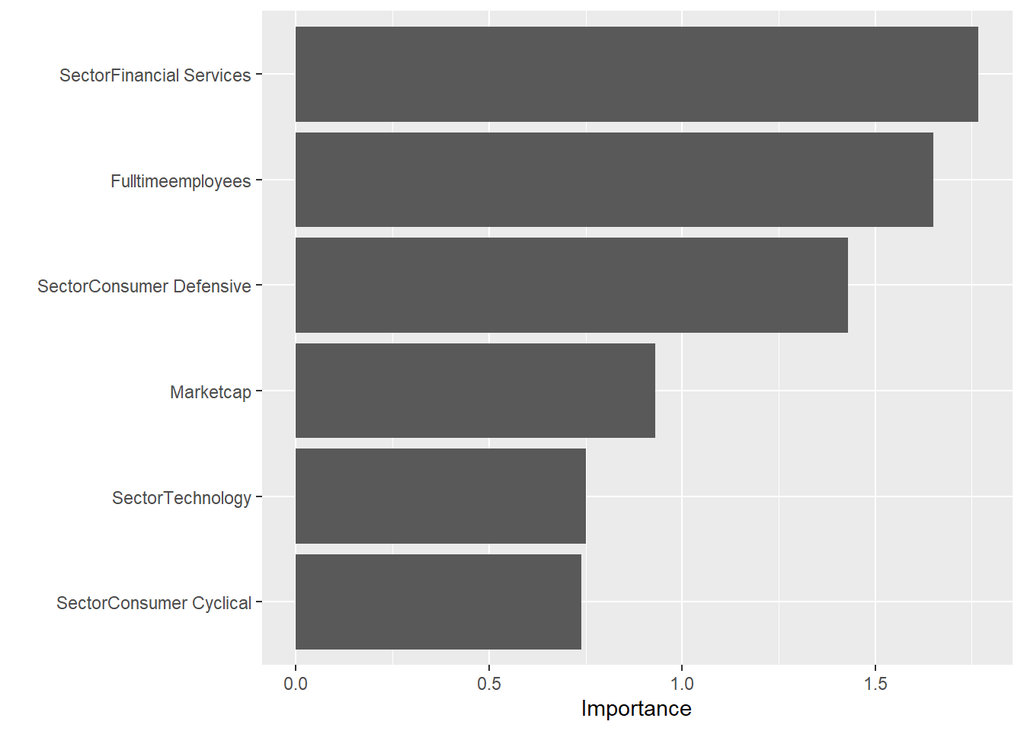

```r
vip(final_fit$fit, num_features =  6)
```

## Gradient Boosting Model

```r
xgb_sp_final <- sp500_final %>%
  mutate(Exceptional_growth_xgb_f = as.numeric(Exceptional_growth)) %>%
  mutate(Exceptional_growth_xgb = ifelse(Exceptional_growth_xgb_f == 1, 0, 1)) %>%
  select(-Exceptional_growth, -Exceptional_growth_xgb_f) %>%
  pivot_wider(names_from = Sector, values_from = Sector, values_fn = length, values_fill = list(Sector = 0))

set.seed(123)
xgb_sp_split <- initial_split(xgb_sp_final, prop = 0.7, strata = "Exceptional_growth_xgb")
xgb_sp_train <- training(xgb_sp_split)
xgb_sp_test <- testing(xgb_sp_split)

xgb_sp_train_matrix <- as.matrix(xgb_sp_train[,-4])
xgb_sp_test_matrix <- as.matrix(xgb_sp_test[,-4])
xgb_sp_train_label <- xgb_sp_train$Exceptional_growth_xgb
xgb_sp_test_label <- xgb_sp_test$Exceptional_growth_xgb


xgb_model <- xgboost(
  data = xgb_sp_train_matrix,
  label = xgb_sp_train_label,
  nrounds = 100,
  max_depth = 4,
  eta = 0.1,
  objective = "binary:logistic",
  verbose = 0
)

xgb_predictions <- predict(xgb_model, xgb_sp_test_matrix)

xgb_rmse <- sqrt(mean((xgb_predictions - xgb_sp_test_label)^2))
print(paste("RMSE (XGBoost):", round(xgb_rmse, 2)))
```

```
## [1] "RMSE (XGBoost): 0.43"
```

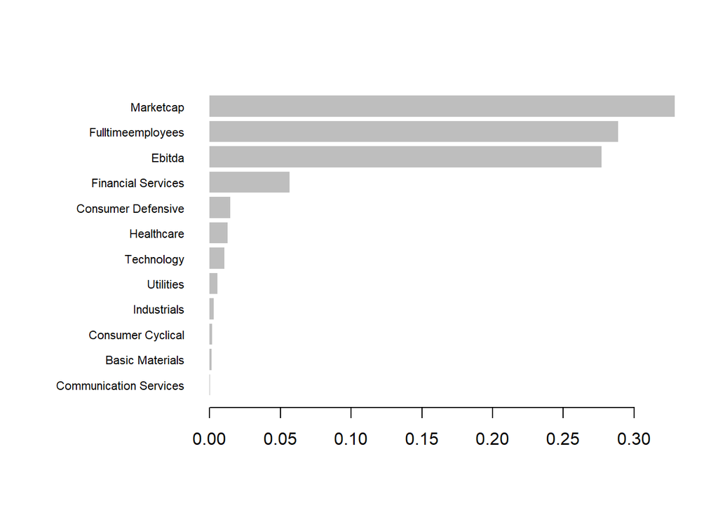

```r
importance <- xgb.importance(feature_names = colnames(xgb_sp_train_matrix), model = xgb_model)
xgb.plot.importance(importance_matrix = importance)
```

## Analysis

**Discoveries**

After reviewing the two models, it was found that no feature has a significant impact on a company’s ability to exceed ten percent revenue growth. The importance of all features in both models never rises above two, which is an extremely small value. Although there is no clear correlation between any of the features in this S&P 500 data set, conducting these models demonstrates that factors contributing to exceptional revenue growth extend beyond market cap, number of full-time employees, EBITDA, and sector.

### Gradient boosting model features

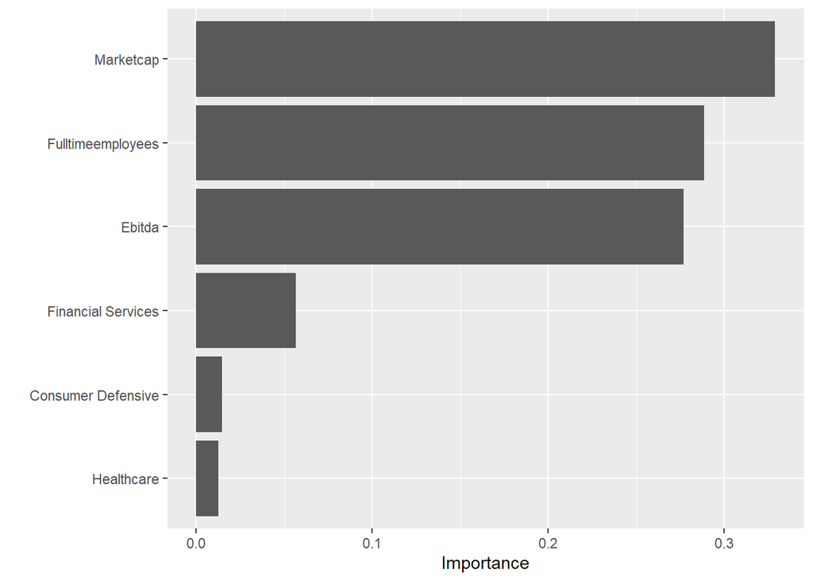

```r
vip(xgb_model, num_features = 6, feature_names = colnames(xgb_sp_train_matrix))
```

### Logistic regression model features

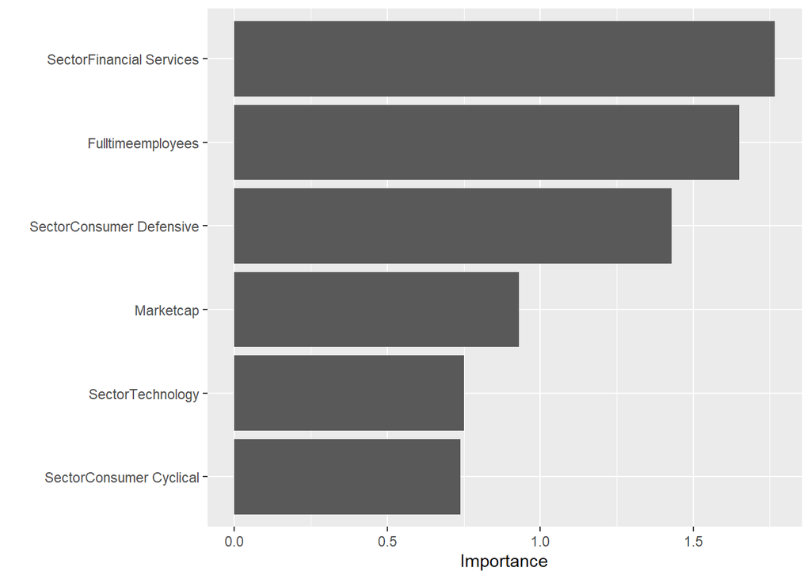

```r
vip(final_fit$fit, num_features =  6)
```